# Tugas Pertemuan 2

# Import Dependencies

```r
library(forecast)
```

```r
library(graphics)
library(TTR)
library(TSA)
library(rio)
library(ggplot2)
library(Metrics)
metrik_evaluasi <- function(aktual, ramalan){
  mae <- Metrics::mae(aktual, ramalan)
  mape <- Metrics::mape(aktual, ramalan)
  mase <- Metrics::mase(aktual, ramalan, step_size = 1)
  mdae <- Metrics::mdae(aktual, ramalan)
  mse <- Metrics::mse(aktual, ramalan)
  rmse <- Metrics::rmse(aktual, ramalan)
  smape <- Metrics::smape(aktual, ramalan)
  sse <- Metrics::sse(aktual, ramalan)

  return(c(mae, mape, mase, mdae, mse, rmse, smape, sse))
}

dma.forecast <- function(sma, dma, n, h = 1) {
  At <- 2 * sma - dma
  Bt <- (2 / (n - 1)) * (sma - dma)

  # Forecast in-sample (1-step ahead)
  Ft_in <- c(NA, At + Bt)

  # Forecast out-of-sample (h-step ahead)
  Ft_out <- At[length(At)] + Bt[length(Bt)] * (1:h)

  return(list(Forecast_in = Ft_in, Forecast_out = Ft_out[-1]))
}
```

# Load Data

```r
data <- import("https://raw.githubusercontent.com/11erlangga/mpdw/refs/heads/main/Pertemuan%201/data/data_erlangga.csv")
data$Date <- as.Date(data$Date, format = "%m/%d/%Y")
head(data)
```

```
##         Date Close   Volume
## 1 2025-02-28  6125 14415600
## 2 2025-03-03  6400 13993600
## 3 2025-03-04  6075 23552800
## 4 2025-03-05  6100  9871600
## 5 2025-03-06  6325 10928500
## 6 2025-03-07  6475 22735800
```

# Eksplorasi Data

```r
str(data)
```

```
## 'data.frame':    112 obs. of  3 variables:
##  $ Date  : Date, format: "2025-02-28" "2025-03-03" ...
##  $ Close : int  6125 6400 6075 6100 6325 6475 6225 6150 6150 6075 ...
##  $ Volume: int  14415600 13993600 23552800 9871600 10928500 22735800 9591300 8972200 5643400 5912700 ...
```

```r
data.bren <- ts(data$Close)
data.bren
```

```
## Time Series:
## Start = 1
## End = 112
## Frequency = 1
##   [1] 6125 6400 6075 6100 6325 6475 6225 6150 6150 6075 6025 5725 5050 5300 5600
##  [16] 5975 5450 5125 5450 5500 4740 4250 5000 5150 5650 5900 5600 5600 5600 6000
##  [31] 6100 6000 6000 6050 6025 6025 6100 6150 6200 6100 5950 6000 6175 6200 6675
##  [46] 6500 6500 6500 6500 6650 6525 6575 6500 6275 6200 6150 6350 6725 6575 6450
##  [61] 6375 6325 6400 6300 6125 6050 5800 5850 5775 5775 5875 5900 5825 5750 5700
##  [76] 5825 6000 5975 6100 6100 7300 7750 7700 7725 8000 7900 7875 7825 7725 7650
##  [91] 7925 7925 7825 7825 7800 7200 7075 7225 7250 7950 8750 9100 9100 9225 8750
## [106] 8575 8600 8425 8525 8925 8875 9800
```

```r
summary(data.bren)
```

```
##    Min. 1st Qu.  Median    Mean 3rd Qu.    Max.
##    4250    5969    6200    6602    7262    9800
```

# Dataset Splitting

```r
n <- nrow(data)
n_train <- floor(0.8 * n)

bren.train <- ts(data.bren[1:n_train],
                 start = start(data.bren),
                 frequency = frequency(data.bren))

bren.test <- ts(data.bren[(n_train+1):n],
                start = time(data.bren)[n_train+1],
                frequency = frequency(data.bren))
```

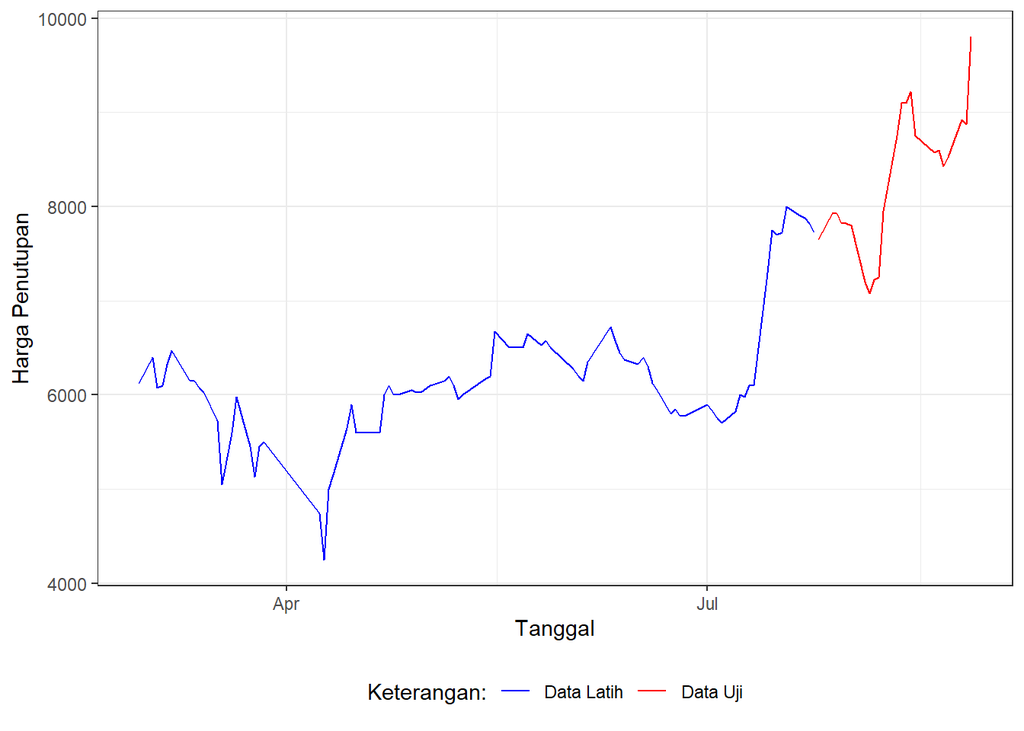

```r
ggplot() +
  geom_line(data = data[1:n_train,], aes(x = Date, y = Close, col = "Data Latih")) +
  geom_line(data = data[n_train+1:n,], aes(x = Date, y = Close, col = "Data Uji")) +
  labs(x = "Tanggal", y = "Harga Penutupan", color = "Legend") +
   scale_colour_manual(name="Keterangan:", breaks = c("Data Latih", "Data Uji"),
                      values = c("blue", "red")) +
  theme_bw() + theme(legend.position = "bottom",
                     plot.caption = element_text(hjust=0.5, size=12))
```

Kombinasi dari adanya tren yang kuat dan tidak adanya pola musiman yang jelas memberikan hipotesis awal untuk pemilihan model. Model peramalan yang cocok untuk kondisi seperti ini adalah model yang mampu menangkap komponen level dan tren. Oleh karena itu, model seperti **Double Exponential Smoothing (DES)** atau **Double Moving Average (DMA)** merupakan kandidat yang sangat sesuai untuk diterapkan pada data ini.

# Single Moving Average

```r
sma.5 <- SMA(bren.train, n=5)
sma.5.ramal <- c(NA, sma.5)

sma.10 <- SMA(bren.train, n=10)
sma.10.ramal <- c(NA, sma.10)

sma.20 <- SMA(bren.train, n=20)
sma.20.ramal <- c(NA, sma.20)

sma.30 <- SMA(bren.train, n=30)
sma.30.ramal <- c(NA, sma.30)
```

```r
sma <- cbind(
  aktual = data$Close,
  pemulusan.5 = c(sma.5, rep(NA, n-n_train)),
  ramalan.5 = c(sma.5.ramal, rep(sma.5.ramal[n_train+1], n-n_train-1)),
  pemulusan.10 = c(sma.10, rep(NA, n-n_train)),
  ramalan.10 = c(sma.10.ramal, rep(sma.10.ramal[n_train+1], n-n_train-1)),
  pemulusan.20 = c(sma.20, rep(NA, n-n_train)),
  ramalan.20 = c(sma.20.ramal, rep(sma.20.ramal[n_train+1], n-n_train-1)),
  pemulusan.30 = c(sma.30, rep(NA, n-n_train)),
  ramalan.30 = c(sma.30.ramal, rep(sma.30.ramal[n_train+1], n-n_train-1))
)
```

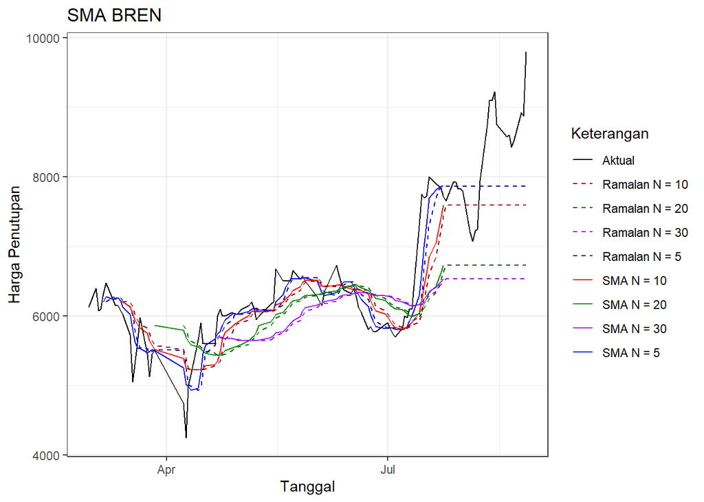

```r
ggplot() +
  geom_line(aes(x = data$Date, y = sma[, "aktual"], color = "Aktual")) +
  geom_line(aes(x = data$Date, y = sma[, "pemulusan.5"], color = "SMA N = 5")) +
  geom_line(aes(x = data$Date, y = sma[, "ramalan.5"], color = "Ramalan N = 5"), linetype="dashed") +
  geom_line(aes(x = data$Date, y = sma[, "pemulusan.10"], color = "SMA N = 10")) +
  geom_line(aes(x = data$Date, y = sma[, "ramalan.10"], color = "Ramalan N = 10"), linetype="dashed") +
  geom_line(aes(x = data$Date, y = sma[, "pemulusan.20"], color = "SMA N = 20")) +
  geom_line(aes(x = data$Date, y = sma[, "ramalan.20"], color = "Ramalan N = 20"), linetype="dashed") +
  geom_line(aes(x = data$Date, y = sma[, "pemulusan.30"], color = "SMA N = 30")) +
  geom_line(aes(x = data$Date, y = sma[, "ramalan.30"], color = "Ramalan N = 30"), linetype="dashed") +

  labs(
    title = "SMA BREN",
    x = "Tanggal",
    y = "Harga Penutupan",
    color = "Keterangan"
  ) +

  scale_color_manual(values = c(
    "Aktual" = "black",
    "SMA N = 5" = "blue", "Ramalan N = 5" = "darkblue",
    "SMA N = 10" = "red", "Ramalan N = 10" = "darkred",
    "SMA N = 20" = "green4", "Ramalan N = 20" = "darkgreen",
    "SMA N = 30" = "purple", "Ramalan N = 30" = "darkviolet"
  )) +

  theme_bw()
```

```r
metrik.sma.train <- data.frame("SMA N 5" = metrik_evaluasi(bren.train[6:n_train], sma[6:n_train, "ramalan.5"]),
                               "SMA N 10" = metrik_evaluasi(bren.train[11:n_train], sma[11:n_train, "ramalan.10"]),
                               "SMA N 20" = metrik_evaluasi(bren.train[21:n_train], sma[21:n_train, "ramalan.20"]),
                               "SMA N 30" = metrik_evaluasi(bren.train[31:n_train], sma[31:n_train, "ramalan.30"]),
                               row.names = c("MAE", "MAPE", "MASE", "MDAE", "MSE", "RMSE", "sMAPE", "SSE")
                               )
metrik.sma.train
```

```
##            SMA.N.5     SMA.N.10     SMA.N.20     SMA.N.30
## MAE   2.584167e+02 3.885316e+02 5.114420e+02 5.499350e+02
## MAPE  4.228521e-02 6.237636e-02 7.995480e-02 8.165130e-02
## MASE  1.494675e+00 2.180250e+00 3.472597e+00 4.508301e+00
## MDAE  1.500000e+02 2.600000e+02 4.025000e+02 4.528333e+02
## MSE   1.569249e+05 2.887287e+05 4.685514e+05 4.916900e+05
## RMSE  3.961375e+02 5.373348e+02 6.845082e+02 7.012061e+02
## sMAPE 4.259669e-02 6.314338e-02 8.185893e-02 8.556828e-02
## SSE   1.318169e+07 2.280957e+07 3.233005e+07 2.900971e+07
```

```r
metrik.sma.test <- data.frame("SMA N 5" = metrik_evaluasi(bren.test, sma[(n_train+1):n, "ramalan.5"]),
                              "SMA N 10" = metrik_evaluasi(bren.test, sma[(n_train+1):n, "ramalan.10"]),
                              "SMA N 20" = metrik_evaluasi(bren.test, sma[(n_train+1):n, "ramalan.20"]),
                              "SMA N 30" = metrik_evaluasi(bren.test, sma[(n_train+1):n, "ramalan.30"]),
                              row.names = c("MAE", "MAPE", "MASE", "MDAE", "MSE", "RMSE", "sMAPE", "SSE")
                              )

metrik.sma.test
```

```
##            SMA.N.5     SMA.N.10     SMA.N.20     SMA.N.30
## MAE   6.758696e+02 8.239130e+02 1.542663e+03 1.738080e+03
## MAPE  7.883641e-02 9.496752e-02 1.800617e-01 2.038655e-01
## MASE  2.655202e+00 3.236801e+00 6.060462e+00 6.828170e+00
## MDAE  6.650000e+02 8.350000e+02 1.693750e+03 1.889167e+03
## MSE   6.987033e+05 9.992304e+05 2.911303e+06 3.552414e+06
## RMSE  8.358847e+02 9.996151e+02 1.706254e+03 1.884785e+03
## sMAPE 8.203324e-02 1.011359e-01 2.013725e-01 2.304334e-01
## SSE   1.607017e+07 2.298230e+07 6.695996e+07 8.170553e+07
```

# Double Moving Average

```r
dma.5 <- SMA(sma.5, n=5)
dma.5.ramal <- dma.forecast(sma.5, dma.5, 5, h=length(bren.test))

dma.10 <- SMA(sma.10, n=10)
dma.10.ramal <- dma.forecast(sma.10, dma.10, 10, h=length(bren.test))

dma.20 <- SMA(sma.20, n=20)
dma.20.ramal <- dma.forecast(sma.20, dma.20, 20, h=length(bren.test))

dma.30 <- SMA(sma.30, n=30)
dma.30.ramal <- dma.forecast(sma.30, dma.30, 30, h=length(bren.test))
```

```r
dma <- cbind(
  aktual = data$Close,
  pemulusan.5 = c(dma.5, rep(NA, n-n_train)),
  ramalan.5 = c(dma.5.ramal$Forecast_in, dma.5.ramal$Forecast_out),
  pemulusan.10 = c(dma.10, rep(NA, n-n_train)),
  ramalan.10 = c(dma.10.ramal$Forecast_in, dma.10.ramal$Forecast_out),
  pemulusan.20 = c(dma.20, rep(NA, n-n_train)),
  ramalan.20 = c(dma.20.ramal$Forecast_in, dma.20.ramal$Forecast_out),
  pemulusan.30 = c(dma.30, rep(NA, n-n_train)),
  ramalan.30 = c(dma.30.ramal$Forecast_in, dma.30.ramal$Forecast_out)
)
```

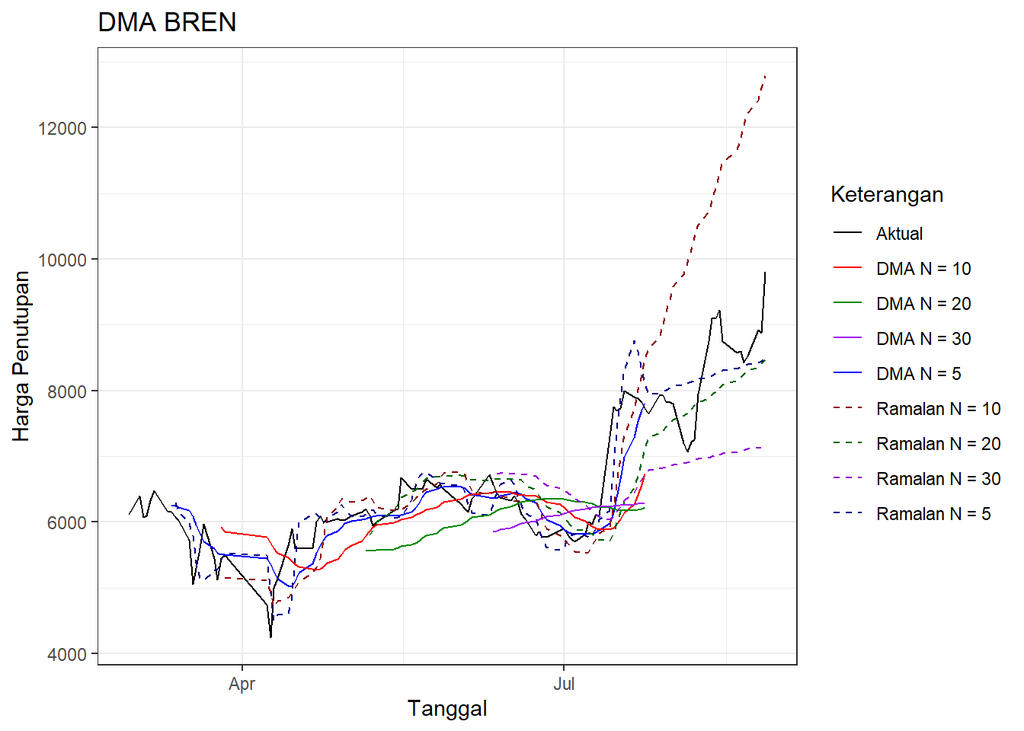

```r
ggplot() +
  geom_line(aes(x = data$Date, y = dma[, "aktual"], color = "Aktual")) +
  geom_line(aes(x = data$Date, y = dma[, "pemulusan.5"], color = "DMA N = 5")) +
  geom_line(aes(x = data$Date, y = dma[, "ramalan.5"], color = "Ramalan N = 5"), linetype="dashed") +
  geom_line(aes(x = data$Date, y = dma[, "pemulusan.10"], color = "DMA N = 10")) +
  geom_line(aes(x = data$Date, y = dma[, "ramalan.10"], color = "Ramalan N = 10"), linetype="dashed") +
  geom_line(aes(x = data$Date, y = dma[, "pemulusan.20"], color = "DMA N = 20")) +
  geom_line(aes(x = data$Date, y = dma[, "ramalan.20"], color = "Ramalan N = 20"), linetype="dashed") +
  geom_line(aes(x = data$Date, y = dma[, "pemulusan.30"], color = "DMA N = 30")) +
  geom_line(aes(x = data$Date, y = dma[, "ramalan.30"], color = "Ramalan N = 30"), linetype="dashed") +

  labs(
    title = "DMA BREN",
    x = "Tanggal",
    y = "Harga Penutupan",
    color = "Keterangan"
  ) +

  scale_color_manual(values = c(
    "Aktual" = "black",
    "DMA N = 5" = "blue", "Ramalan N = 5" = "darkblue",
    "DMA N = 10" = "red", "Ramalan N = 10" = "darkred",
    "DMA N = 20" = "green4", "Ramalan N = 20" = "darkgreen",
    "DMA N = 30" = "purple", "Ramalan N = 30" = "darkviolet"
  )) +

  theme_bw()
```

```r
metrik.dma.train <- data.frame("DMA N 5" = metrik_evaluasi(bren.train[10:n_train], dma[10:n_train, "ramalan.5"]),
                               "DMA N 10" = metrik_evaluasi(bren.train[20:n_train], dma[20:n_train, "ramalan.10"]),
                               "DMA N 20" = metrik_evaluasi(bren.train[40:n_train], dma[40:n_train, "ramalan.20"]),
                               "DMA N 30" = metrik_evaluasi(bren.train[60:n_train], dma[60:n_train, "ramalan.30"]),
                               row.names = c("MAE", "MAPE", "MASE", "MDAE", "MSE", "RMSE", "sMAPE", "SSE")
                               )
metrik.dma.train
```

```
##            DMA.N.5     DMA.N.10     DMA.N.20     DMA.N.30
## MAE   2.770925e+02 3.428951e+02 4.542191e+02 7.687652e+02
## MAPE  4.538509e-02 5.470210e-02 6.573997e-02 1.129102e-01
## MASE  1.569198e+00 2.195801e+00 3.359508e+00 5.608602e+00
## MDAE  1.790000e+02 2.758194e+02 2.822296e+02 6.580236e+02
## MSE   1.509778e+05 2.085037e+05 4.541636e+05 8.175690e+05
## RMSE  3.885586e+02 4.566221e+02 6.739166e+02 9.041952e+02
## sMAPE 4.580233e-02 5.592225e-02 6.849399e-02 1.154075e-01
## SSE   1.207822e+07 1.459526e+07 2.270818e+07 2.452707e+07
```

```r
metrik.dma.test <- data.frame("DMA N 5" = metrik_evaluasi(bren.test, dma[(n_train+1):n, "ramalan.5"]),
                              "DMA N 10" = metrik_evaluasi(bren.test, dma[(n_train+1):n, "ramalan.10"]),
                              "DMA N 20" = metrik_evaluasi(bren.test, dma[(n_train+1):n, "ramalan.20"]),
                              "DMA N 30" = metrik_evaluasi(bren.test, dma[(n_train+1):n, "ramalan.30"]),
                              row.names = c("MAE", "MAPE", "MASE", "MDAE", "MSE", "RMSE", "sMAPE", "SSE")
                              )

metrik.dma.test
```

```
##            DMA.N.5     DMA.N.10     DMA.N.20     DMA.N.30
## MAE   5.025217e+02 2.438254e+03 5.701778e+02 1.296007e+03
## MAPE  6.097147e-02 2.951604e-01 6.740052e-02 1.508712e-01
## MASE  1.974193e+00 9.578854e+00 2.239984e+00 5.091456e+00
## MDAE  4.220000e+02 2.572944e+03 4.941743e+02 1.330320e+03
## MSE   3.893109e+05 6.716334e+06 4.356822e+05 2.105619e+06
## RMSE  6.239478e+02 2.591589e+03 6.600623e+02 1.451075e+03
## sMAPE 6.085116e-02 2.534294e-01 6.953697e-02 1.659581e-01
## SSE   8.954150e+06 1.544757e+08 1.002069e+07 4.842923e+07
```

# Single Exponential Smoothing

```r
ses <- HoltWinters(bren.train, gamma = FALSE, beta = FALSE, alpha = NULL)
ses.ramal <- forecast(ses, h=length(bren.test))
ses
```

```
## Holt-Winters exponential smoothing without trend and without seasonal component.
##
## Call:
## HoltWinters(x = bren.train, alpha = NULL, beta = FALSE, gamma = FALSE)
##
## Smoothing parameters:
##  alpha: 0.9999298
##  beta : FALSE
##  gamma: FALSE
##
## Coefficients:
##       [,1]
## a 7725.007
```

```r
length(c(NA, ses$fitted[, "xhat"], rep(NA, n-n_train)))
```

```
## [1] 112
```

```r
length(c(rep(NA, n_train), as.numeric(ses.ramal$mean)))
```

```
## [1] 112
```

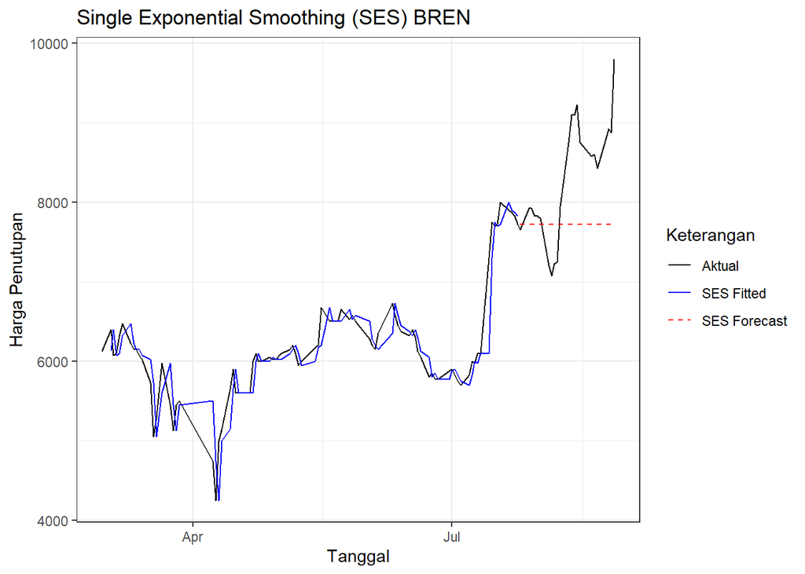

```r
df_plot <- data.frame(
  Date = data$Date,
  Aktual = data$Close,
  Fitted = c(NA, ses$fitted[, "xhat"], rep(NA, n-n_train)),
  Forecast = c(rep(NA, n_train), as.numeric(ses.ramal$mean))
)

ggplot(df_plot, aes(x = Date)) +
  geom_line(aes(y = Aktual, color = "Aktual")) +
  geom_line(aes(y = Fitted, color = "SES Fitted")) +
  geom_line(aes(y = Forecast, color = "SES Forecast"), linetype = "dashed") +

  labs(
    title = "Single Exponential Smoothing (SES) BREN",
    x = "Tanggal",
    y = "Harga Penutupan",
    color = "Keterangan"
  ) +

  scale_color_manual(values = c(
    "Aktual" = "black",
    "SES Fitted" = "blue",
    "SES Forecast" = "red"
  )) +

  theme_bw()
```

```r
metrik.ses.train <- data.frame("SES" = metrik_evaluasi(bren.train[2:n_train], ses$fitted[, "xhat"]),
                               row.names = c("MAE", "MAPE", "MASE", "MDAE", "MSE", "RMSE", "sMAPE", "SSE")
                               )
metrik.ses.train
```

```
##                SES
## MAE   1.744345e+02
## MAPE  2.957767e-02
## MASE  1.006686e+00
## MDAE  9.999561e+01
## MSE   7.121098e+04
## RMSE  2.668538e+02
## sMAPE 2.968829e-02
## SSE   6.266566e+06
```

```r
metrik.ses.test <- data.frame("SES" = metrik_evaluasi(bren.test, ses.ramal$mean),
                               row.names = c("MAE", "MAPE", "MASE", "MDAE", "MSE", "RMSE", "sMAPE", "SSE")
                               )

metrik.ses.test
```

```
##                SES
## MAE   7.423873e+02
## MAPE  8.590881e-02
## MASE  2.916522e+00
## MDAE  6.999930e+02
## MSE   8.327912e+05
## RMSE  9.125739e+02
## sMAPE 9.053764e-02
## SSE   1.915420e+07
```

# Double Exponential Smoothing

```r
des <- HoltWinters(bren.train, gamma = FALSE, beta = NULL, alpha = NULL)
des.ramal <- forecast(des, h=length(bren.test))
des
```

```
## Holt-Winters exponential smoothing with trend and without seasonal component.
##
## Call:
## HoltWinters(x = bren.train, alpha = NULL, beta = NULL, gamma = FALSE)
##
## Smoothing parameters:
##  alpha: 1
##  beta : 0.112341
##  gamma: FALSE
##
## Coefficients:
##         [,1]
## a 7725.00000
## b   70.26167
```

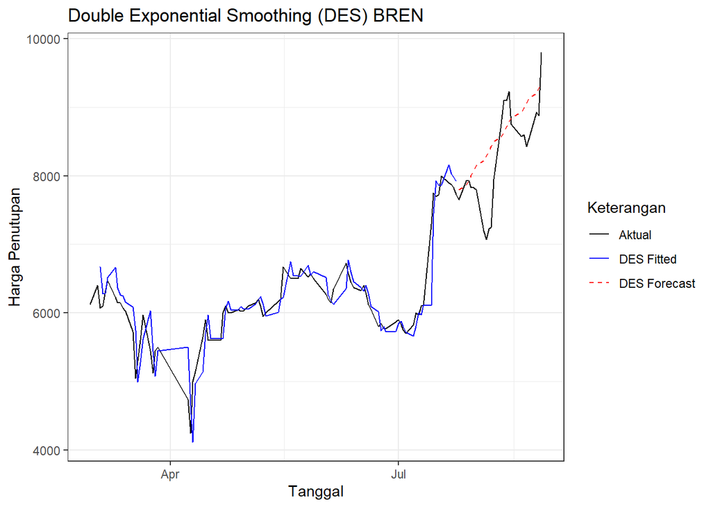

```r
df_plot <- data.frame(
  Date = data$Date,
  Aktual = data$Close,
  Fitted = c(NA, NA, des$fitted[, "xhat"], rep(NA, n-n_train)),
  Forecast = c(rep(NA, n_train), as.numeric(des.ramal$mean))
)

ggplot(df_plot, aes(x = Date)) +
  geom_line(aes(y = Aktual, color = "Aktual")) +
  geom_line(aes(y = Fitted, color = "DES Fitted")) +
  geom_line(aes(y = Forecast, color = "DES Forecast"), linetype = "dashed") +

  labs(
    title = "Double Exponential Smoothing (DES) BREN",
    x = "Tanggal",
    y = "Harga Penutupan",
    color = "Keterangan"
  ) +

  scale_color_manual(values = c(
    "Aktual" = "black",
    "DES Fitted" = "blue",
    "DES Forecast" = "red"
  )) +

  theme_bw()
```

```r
metrik.des.train <- data.frame("DES" = metrik_evaluasi(bren.train[3:n_train], des$fitted[, "xhat"]),
                               row.names = c("MAE", "MAPE", "MASE", "MDAE", "MSE", "RMSE", "sMAPE", "SSE")
                               )
metrik.des.train
```

```
##                DES
## MAE   1.958741e+02
## MAPE  3.300743e-02
## MASE  1.142046e+00
## MDAE  1.433266e+02
## MSE   8.128362e+04
## RMSE  2.851028e+02
## sMAPE 3.302230e-02
## SSE   7.071675e+06
```

```r
metrik.des.test <- data.frame("DES" = metrik_evaluasi(bren.test, des.ramal$mean),
                               row.names = c("MAE", "MAPE", "MASE", "MDAE", "MSE", "RMSE", "sMAPE", "SSE")
                               )

metrik.des.test
```

```
##                DES
## MAE   4.680816e+02
## MAPE  5.897847e-02
## MASE  1.838892e+00
## MDAE  3.913366e+02
## MSE   3.393221e+05
## RMSE  5.825136e+02
## sMAPE 5.661874e-02
## SSE   7.804408e+06
```

# Perbandingan Metrik Evaluasi

```r
metrik.train <- rbind(
  t(metrik.sma.train),
  t(metrik.dma.train),
  t(metrik.ses.train),
  t(metrik.des.train)
)

metrik.train
```

```
##               MAE       MAPE     MASE      MDAE       MSE     RMSE      sMAPE
## SMA.N.5  258.4167 0.04228521 1.494675 150.00000 156924.94 396.1375 0.04259669
## SMA.N.10 388.5316 0.06237636 2.180250 260.00000 288728.70 537.3348 0.06314338
## SMA.N.20 511.4420 0.07995480 3.472597 402.50000 468551.44 684.5082 0.08185893
## SMA.N.30 549.9350 0.08165130 4.508301 452.83333 491689.95 701.2061 0.08556828
## DMA.N.5  277.0925 0.04538509 1.569198 179.00000 150977.78 388.5586 0.04580233
## DMA.N.10 342.8951 0.05470210 2.195801 275.81944 208503.75 456.6221 0.05592225
## DMA.N.20 454.2191 0.06573997 3.359508 282.22961 454163.63 673.9166 0.06849399
## DMA.N.30 768.7652 0.11291023 5.608602 658.02356 817569.00 904.1952 0.11540754
## SES      174.4345 0.02957767 1.006686  99.99561  71210.98 266.8538 0.02968829
## DES      195.8741 0.03300743 1.142046 143.32656  81283.62 285.1028 0.03302230
##               SSE
## SMA.N.5  13181695
## SMA.N.10 22809568
## SMA.N.20 32330049
## SMA.N.30 29009707
## DMA.N.5  12078222
## DMA.N.10 14595262
## DMA.N.20 22708181
## DMA.N.30 24527070
## SES       6266566
## DES       7071675
```

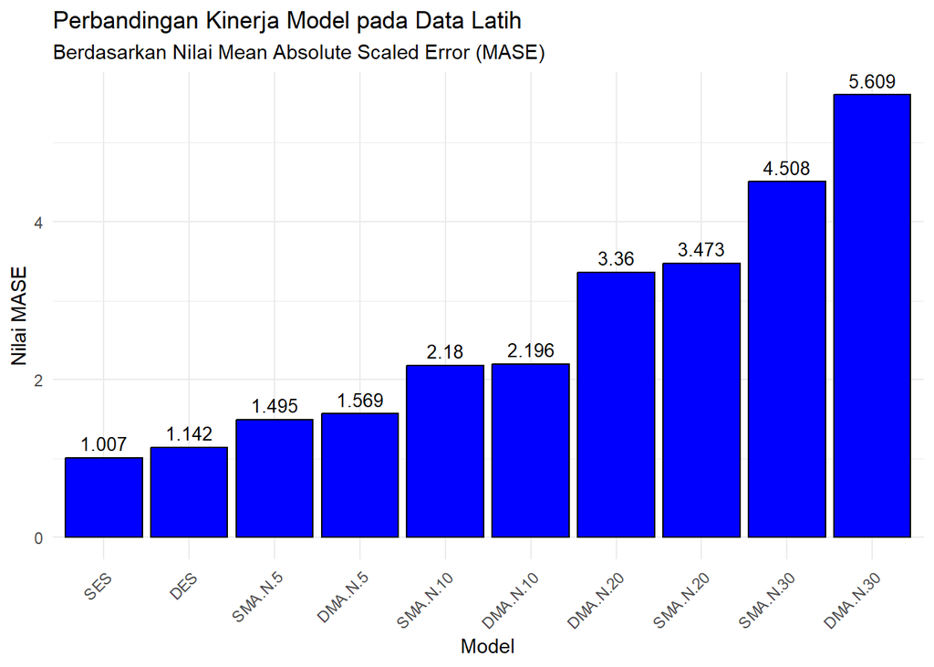

```r
metrik.train <- as.data.frame(metrik.train)
metrik.train$Model <- rownames(metrik.train)

ggplot(data = metrik.train, aes(x = reorder(Model, MASE), y = MASE)) +
  geom_bar(stat = "identity", fill = "blue", color = "black") +

  geom_text(aes(label = round(MASE, 3)), vjust = -0.5, size = 3.5) +

  labs(
    title = "Perbandingan Kinerja Model pada Data Latih",
    subtitle = "Berdasarkan Nilai Mean Absolute Scaled Error (MASE)",
    x = "Model",
    y = "Nilai MASE"
  ) +

  theme_minimal() +
  theme(axis.text.x = element_text(angle = 45, hjust = 1))
```

```r
metrik.test <- rbind(
  t(metrik.sma.test),
  t(metrik.dma.test),
  t(metrik.ses.test),
  t(metrik.des.test)
)

metrik.test
```

```
##                MAE       MAPE     MASE      MDAE       MSE      RMSE      sMAPE
## SMA.N.5   675.8696 0.07883641 2.655202  665.0000  698703.3  835.8847 0.08203324
## SMA.N.10  823.9130 0.09496752 3.236801  835.0000  999230.4  999.6151 0.10113592
## SMA.N.20 1542.6630 0.18006170 6.060462 1693.7500 2911302.6 1706.2540 0.20137251
## SMA.N.30 1738.0797 0.20386554 6.828170 1889.1667 3552414.5 1884.7850 0.23043345
## DMA.N.5   502.5217 0.06097147 1.974193  422.0000  389310.9  623.9478 0.06085116
## DMA.N.10 2438.2536 0.29516044 9.578854 2572.9444 6716334.2 2591.5891 0.25342944
## DMA.N.20  570.1778 0.06740052 2.239984  494.1743  435682.2  660.0623 0.06953697
## DMA.N.30 1296.0069 0.15087116 5.091456 1330.3199 2105618.9 1451.0751 0.16595810
## SES       742.3873 0.08590881 2.916522  699.9930  832791.2  912.5739 0.09053764
## DES       468.0816 0.05897847 1.838892  391.3366  339322.1  582.5136 0.05661874
##                SSE
## SMA.N.5   16070175
## SMA.N.10  22982300
## SMA.N.20  66959961
## SMA.N.30  81705533
## DMA.N.5    8954150
## DMA.N.10 154475687
## DMA.N.20  10020692
## DMA.N.30  48429235
## SES       19154198
## DES        7804408
```

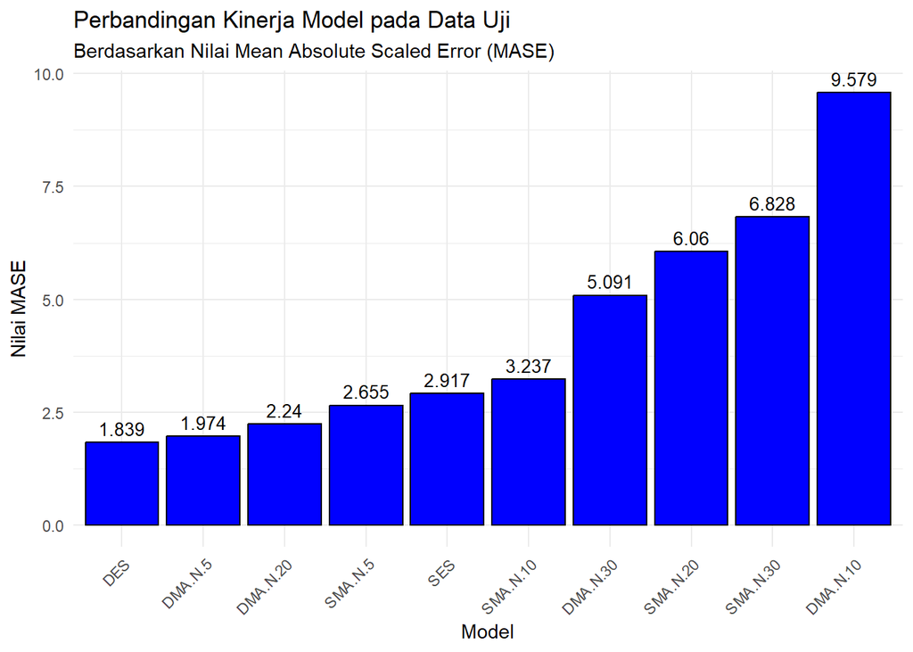

```r
metrik.test <- as.data.frame(metrik.test)
metrik.test$Model <- rownames(metrik.test)

ggplot(data = metrik.test, aes(x = reorder(Model, MASE), y = MASE)) +
  geom_bar(stat = "identity", fill = "blue", color = "black") +

  geom_text(aes(label = round(MASE, 3)), vjust = -0.5, size = 3.5) +

  labs(
    title = "Perbandingan Kinerja Model pada Data Uji",
    subtitle = "Berdasarkan Nilai Mean Absolute Scaled Error (MASE)",
    x = "Model",
    y = "Nilai MASE"
  ) +

  theme_minimal() +
  theme(axis.text.x = element_text(angle = 45, hjust = 1))
```

Beberapa alasan saya menggunakan MASE:

1. Independen Terhadap Skala  
   MASE tidak terpengaruh oleh skala asli data (apakah data dalam puluhan atau jutaan). Ini membuatnya adil saat membandingkan data set yang berbeda.
2. Menghindari Masalah Pembagian dengan Nol  
   MAPE akan gagal jika ada nilai aktual nol dalam data. MASE tidak memiliki masalah ini.
3. Simetris  
   MAPE cenderung memberikan “hukuman” lebih besar pada peramalan yang terlalu rendah daripada yang terlalu tinggi. MASE lebih simetris dan adil.
4. Benchmark yang Jelas  
   MASE memiliki interpretasi yang sangat kuat. Nilai MASE < 1 berarti model Anda lebih baik daripada model naive (yang meramalkan nilai periode sebelumnya). Nilai MASE > 1 berarti model Anda lebih buruk daripada model naif. Ini memberikan dasar perbandingan yang sangat jelas.

> Kesimpulan Awal: Model SES dan DES menunjukkan kemampuan terbaik untuk menyesuaikan diri (fitting) dengan pola pada data latih.

Pada data uji,

- Berdasarkan MASE  
  Peringkat model berubah secara signifikan. Model DES (MASE: 1.839) menjadi pemenang yang jelas, diikuti oleh DMA.N.5 (MASE: 1.974). Yang menarik, SES—model terbaik pada data latih—menunjukkan kinerja yang jauh lebih buruk di sini (MASE: 2.917). Ini adalah indikasi bahwa model SES mengalami overfitting; ia terlalu “menghafal” data latih dan gagal menggeneralisasi polanya ke data baru.
- Berdasarkan MAPE  
  BLagi-lagi, MAPE mengonfirmasi temuan MASE. DES (5.90%) dan DMA.N.5 (6.09%) menunjukkan persentase kesalahan terkecil. Ini berarti, pada data uji, ramalan dari model DES rata-rata hanya meleset sekitar 5.90% dari nilai aktual.

> Kesimpulan dan Pemilihan Model Terbaik: Berdasarkan analisis gabungan dari data latih dan data uji, model DES (Double Exponential Smoothing) adalah model terbaik secara keseluruhan.

Meskipun SES menunjukkan performa sedikit lebih baik pada data latih, kemampuannya untuk melakukan generalisasi pada data uji sangat buruk. Sebaliknya, DES menunjukkan kinerja yang kuat baik saat fitting (peringkat 2 pada data latih) maupun saat melakukan peramalan (peringkat 1 pada data uji), menjadikannya pilihan yang paling seimbang dan andal.

Penting juga untuk dicatat bahwa semua model memiliki nilai MASE di atas 1 pada data uji, yang berarti tidak ada model yang berhasil mengalahkan performa model naif pada data baru. Ini menunjukkan bahwa data saham ini sangat sulit diprediksi.